# Tutorial: Designs and Data Formats for `contrast_analysis()`

Between-Subjects, Within-Subjects, and How to Set Up Your Data

# 1 Prerequisites

This tutorial assumes you have already read the main tutorial (`vignette("tutorial")`), which covers the core logic of contrast analysis with equivalence testing, the three possible conclusions (SUPPORTED, PARTIALLY SUPPORTED, NOT SUPPORTED), and the `hypothesis`, `delta`, and `share_signal` arguments. Here, we focus on something that tutorial covered only briefly: **how different experimental designs change the way you set up your data and call the function**.

The two designs the function supports are:

| Design | Setting | Data format | Key arguments |
| --- | --- | --- | --- |
| **Between-subjects** | Different people in each condition | Long format (one row per observation) | `dv`, `conditions` |
| **Within-subjects** | Same people measured in every condition | Wide format (one row per person) | `id`, `dv = NULL`, `conditions = NULL` |

We will walk through each design in detail, with realistic examples that show exactly what the data look like, how the function call changes, and how the output differs.

```r
library(contrastanalysis)
library(MASS)
library(ggplot2)
set.seed(2025)
```

# 2 Part 1: Between-Subjects Designs

In a between-subjects design, each participant is assigned to exactly one condition. The data are in **long format**: each row is one participant, and you have a column for the dependent variable and a column that identifies which condition (group) the participant belongs to.

## 2.1 What the data look like

Imagine an experiment testing whether exposure to increasingly violent video game content produces a dose–response increase in aggressive behavior. There are four independent groups: *None*, *Mild*, *Moderate*, and *Extreme*, with 60 participants per group.

```r
n_per <- 60

data_between <- data.frame(
  participant = 1:(4 * n_per),
  condition   = rep(c("None", "Mild", "Moderate", "Extreme"), each = n_per),
  aggression  = c(
    rnorm(n_per, mean = 3.0, sd = 2.5),
    rnorm(n_per, mean = 4.5, sd = 2.5),
    rnorm(n_per, mean = 6.0, sd = 2.5),
    rnorm(n_per, mean = 7.5, sd = 2.5)
  )
)

head(data_between)
```

```
##   participant condition aggression
## 1           1      None   4.551892
## 2           2      None   3.089104
## 3           3      None   4.932886
## 4           4      None   6.181223
## 5           5      None   3.927439
## 6           6      None   2.592864
```

Notice the structure: each row is a unique participant, `condition` tells us which group they are in, and `aggression` is the score. This is the standard “one observation per row” format that `lm()` expects.

## 2.2 The function call

For between-subjects designs you need to tell the function two things about your data frame:

- `dv` — the name of the dependent variable column, as a string.
- `conditions` — the name of the grouping variable column, as a string.

The `hypothesis` names must match the levels of the `conditions` column.

```
##
## =================================================================
##       CONTRAST ANALYSIS WITH EQUIVALENCE TESTING
## =================================================================
##
## Design:  between-subjects
## Groups:  None, Mild, Moderate, Extreme (k = 4)
## N:       240
## Alpha:   0.05
## Orthogonal contrasts: Yes
## Effect size metric: d = b / sigma (b = contrast coefficient, sigma = sqrt(MSE))
##
## Hypothesized pattern: None < Mild < Moderate < Extreme
##
## ----- Contrast Weights -----
##                 InterestResidual 1Residual 2
##   None           -0.6708   -0.4236   -0.3472
##   Mild           -0.2236    0.3060    0.7787
##   Moderate        0.2236    0.6588   -0.5157
##   Extreme         0.6708   -0.5412    0.0843
##
##   Note: Residual contrasts are one possible orthonormal basis for the
##   subspace orthogonal to the predicted pattern. Individual residual
##   vectors are not uniquely defined, but their joint test is invariant:
##   if any systematic deviation from the predicted pattern exists, at
##   least one residual will detect it.
##
## ----- Contrast of Interest (NHST) -----
##   b = 3.281, SE = 0.316, t(236) = 10.382, p < .001 [SIGNIFICANT]
##   d = 1.340, 95% CI [1.086, 1.595]
##
## ----- Residual Contrasts (TOST Equivalence Tests) -----
##   Equivalence bounds (standardized): +/-0.300, +/-0.300
##
##   Residual 1:
##     Weights: None: -0.424, Mild: +0.306, Moderate: +0.659, Extreme: -0.541
##     NHST: b = -0.498, SE = 0.316, t(236) = -1.576, p = 0.116
##     TOST: d = -0.203, 90% CI [-0.417, 0.010]
##           p1 = 0.228, p2 < .001, p_TOST = 0.228 [NOT equivalent]
##
```

[output cut: 9 more lines]

```
##   Residual 2:           1.2%
##
## =================================================================
##   CONCLUSION: PARTIALLY SUPPORTED
## =================================================================
##   The data partially support the hypothesized pattern. The
##   contrast of interest is statistically significant, but not all
##   residual contrasts could be declared equivalent to zero. The
##   hypothesized pattern does not fully account for the
##   between-condition differences.
##
## ----- APA-Formatted Results -----
## Contrast of interest: b = 3.28, SE = 0.32, t(236) = 10.38, p < .001, d = 1.34, 95% CI [1.09, 1.59].
## Residual contrast 1 (TOST): b = -0.50, SE = 0.32, d = -0.20, 90% CI [-0.42, 0.01], equivalence bounds = +/-0.30, t1(236) = 0.75, p1 = .228, t2(236) = -3.90, p2 < .001, p_TOST = .228 (not equivalent to zero).
## Residual contrast 2 (TOST): b = -0.37, SE = 0.32, d = -0.15, 90% CI [-0.36, 0.06], equivalence bounds = +/-0.30, t1(236) = 1.15, p1 = .126, t2(236) = -3.50, p2 < .001, p_TOST = .126 (not equivalent to zero).
```

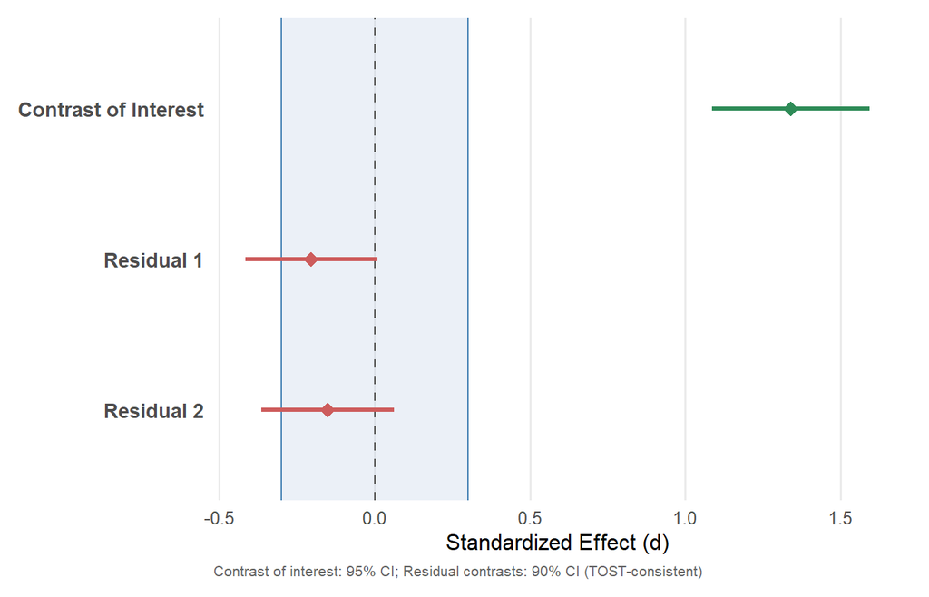

```r
result_between <- contrast_analysis(
  data       = data_between,
  dv         = "aggression",
  conditions = "condition",
  hypothesis = c(None = 0, Mild = 1, Moderate = 2, Extreme = 3),
  delta      = 0.3,
  graph1     = TRUE,
  graph2     = FALSE
)
```

### 2.2.1 What happens under the hood

The function fits a standard linear model: `lm(aggression ~ condition)`. The contrast weights are applied to the group means estimated from this model, and the residual standard error (sqrt of MSE) serves as the denominator for the standardized effect size *d*. The effect size metric is reported as:

> d = b / sigma (b = contrast coefficient, sigma = sqrt(MSE))

This is the between-subjects standardization. The degrees of freedom are *N* − *k*, where *N* is the total sample size and *k* is the number of groups.

## 2.3 Practical tips for between-subjects data

**Factor ordering.** The function matches hypothesis names to data levels, not positions. So `c(Extreme = 3, None = 0, Mild = 1, Moderate = 2)` is identical to what we wrote above. You do not need to set factor levels manually.

**Unbalanced groups.** The function handles unequal group sizes. The linear model accommodates this automatically. However, the variance decomposition percentages are most cleanly interpretable with balanced designs.

**Character vs. factor.** The `conditions` column can be either a character vector or a factor. The function will convert characters to factors internally.

# 3 Part 2: Within-Subjects Designs

In a within-subjects (repeated-measures) design, the same participant provides a score in every condition. This is common in psychology: the same person plays multiple game types, rates multiple stimuli, or is tested across multiple time points.

## 3.1 What the data look like

The critical difference is that within-subjects data must be in **wide format**: one row per participant, with a separate column for each condition.

Imagine a study where 50 participants each play three video games — *Puzzle*, *Action*, and *Violent* — and we measure their heart rate during play. We predict that heart rate increases across the three types.

```r
n <- 50

# Simulate correlated data (rho = 0.6 between conditions)
Sigma <- matrix(c(
  100, 60, 60,
   60, 100, 60,
   60,  60, 100
), nrow = 3)

scores <- MASS::mvrnorm(n, mu = c(72, 78, 85), Sigma = Sigma)

data_within <- data.frame(
  pid    = 1:n,
  Puzzle = scores[, 1],
  Action = scores[, 2],
  Violent = scores[, 3]
)

head(data_within)
```

```
##   pid   Puzzle   Action  Violent
## 1   1 73.08390 80.59093 78.55731
## 2   2 85.63782 78.26788 81.52543
## 3   3 58.52963 60.10652 77.79988
## 4   4 71.81925 80.45840 89.48979
## 5   5 79.26900 90.22281 87.06021
## 6   6 77.09195 77.64759 91.18991
```

Each row is one participant. The columns `Puzzle`, `Action`, and `Violent` hold that participant’s score in each condition. There is no `condition` column — the conditions *are* the column names.

## 3.2 The function call

The within-subjects call differs from the between-subjects call in four important ways:

| Argument | Between-subjects | Within-subjects |
| --- | --- | --- |
| `dv` | Name of the DV column | `NULL` |
| `conditions` | Name of the grouping column | `NULL` |
| `design` | `"between"` (default) | `"within"` |
| `id` | Not needed | Name of the participant ID column |

Setting `dv = NULL` and `conditions = NULL` tells the function: “The condition names are the column names in the data frame, and the values in those columns are the repeated measurements.” The `hypothesis` names must match these column names.

```
##
## =================================================================
##       CONTRAST ANALYSIS WITH EQUIVALENCE TESTING
## =================================================================
##
## Design:  within-subjects
## Groups:  Puzzle, Action, Violent (k = 3)
## N:       50
## Alpha:   0.05
## Orthogonal contrasts: Yes
## Effect size metric: d_z = M / SD (M and SD of within-subject contrast scores)
##
## Hypothesized pattern: Puzzle < Action < Violent
##
## ----- Contrast Weights -----
##                 InterestResidual 1
##   Puzzle         -0.7071    0.4082
##   Action          0.0000   -0.8165
##   Violent         0.7071    0.4082
##
##   Note: Residual contrasts are one possible orthonormal basis for the
##   subspace orthogonal to the predicted pattern. Individual residual
##   vectors are not uniquely defined, but their joint test is invariant:
##   if any systematic deviation from the predicted pattern exists, at
##   least one residual will detect it.
##
## ----- Contrast of Interest (NHST) -----
##   b = 8.739, SE = 0.875, t(49) = 9.982, p < .001 [SIGNIFICANT]
##   d = 1.412, 95% CI [1.010, 1.813]
##
## ----- Residual Contrasts (TOST Equivalence Tests) -----
##   Equivalence bounds (standardized): +/-0.300
##
##   Residual 1:
##     Weights: Puzzle: +0.408, Action: -0.816, Violent: +0.408
##     NHST: b = 0.034, SE = 0.929, t(49) = 0.037, p = 0.971
##     TOST: d = 0.005, 90% CI [-0.232, 0.242]
##           p1 = 0.018, p2 = 0.021, p_TOST = 0.021 [EQUIVALENT (within bounds)]
##
## ----- Variance Decomposition -----
##   Contrast of Interest: 100.0%
##   Residual 1:           0.0%
##
## =================================================================
##   CONCLUSION: SUPPORTED
## =================================================================
##   The data fully support the hypothesized pattern. The contrast
##   of interest is statistically significant, and all residual
##   contrasts are equivalent to zero (within the specified
##   equivalence bounds).
##
## ----- APA-Formatted Results -----
## Contrast of interest: b = 8.74, SE = 0.88, t(49) = 9.98, p < .001, d = 1.41, 95% CI [1.01, 1.81].
## Residual contrast 1 (TOST): b = 0.03, SE = 0.93, d = 0.01, 90% CI [-0.23, 0.24], equivalence bounds = +/-0.30, t1(49) = 2.16, p1 = .018, t2(49) = -2.08, p2 = .021, p_TOST = .021 (equivalent to zero).
```

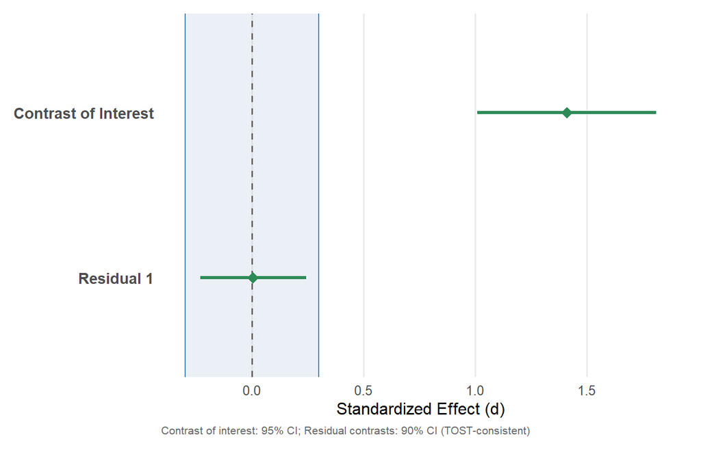

```r
result_within <- contrast_analysis(
  data       = data_within,
  dv         = NULL,
  conditions = NULL,
  hypothesis = c(Puzzle = 0, Action = 1, Violent = 2),
  design     = "within",
  id         = "pid",
  delta      = 0.3,
  graph1     = TRUE,
  graph2     = FALSE
)
```

### 3.2.1 What happens under the hood

The function does **not** fit `lm()`. Instead, it computes within-subject contrast scores directly. For each participant, it takes the vector of scores across conditions and multiplies it by the contrast weights. This produces a single contrast score per participant per contrast. The test is then a one-sample *t*-test on these scores (testing whether the mean differs from zero).

The effect size metric is:

> d_z = M / SD (M and SD of within-subject contrast scores)

This is Cohen’s *d_z* — the paired-samples standardization. The degrees of freedom are *n* − 1, where *n* is the number of participants. Because within-subjects designs remove between-person variability, *d_z* is typically larger than the between-subjects *d* for the same true effect, and equivalence tests have more power.

## 3.3 Why wide format?

You might wonder: “Why not long format like between-subjects?” The reason is that within-subjects contrast analysis requires computing scores *within* each participant. With wide format, each participant’s full data vector is in one row, making the contrast score calculation straightforward: multiply the row by the weight vector.

If your data are currently in long format, you need to pivot to wide first. Here is how:

```r
# Suppose you have long-format within-subjects data:
data_long <- data.frame(
  pid       = rep(1:50, each = 3),
  condition = rep(c("Puzzle", "Action", "Violent"), times = 50),
  hr        = c(t(scores))     # flatten the score matrix row-wise
)

head(data_long, 9)  # first 3 participants
```

```
##   pid condition       hr
## 1   1    Puzzle 73.08390
## 2   1    Action 80.59093
## 3   1   Violent 78.55731
## 4   2    Puzzle 85.63782
## 5   2    Action 78.26788
## 6   2   Violent 81.52543
## 7   3    Puzzle 58.52963
## 8   3    Action 60.10652
## 9   3   Violent 77.79988
```

```r
# Pivot to wide format:
data_wide <- reshape(data_long,
                     idvar     = "pid",
                     timevar   = "condition",
                     direction = "wide")

# Clean up column names (reshape adds "hr." prefix)
names(data_wide) <- gsub("hr\\.", "", names(data_wide))

head(data_wide)
```

```
##    pid   Puzzle   Action  Violent
## 1    1 73.08390 80.59093 78.55731
## 4    2 85.63782 78.26788 81.52543
## 7    3 58.52963 60.10652 77.79988
## 10   4 71.81925 80.45840 89.48979
## 13   5 79.26900 90.22281 87.06021
## 16   6 77.09195 77.64759 91.18991
```

Now `data_wide` is in the correct format for `contrast_analysis()`.

If you use `tidyr`, the equivalent is:

```r
library(tidyr)
data_wide <- pivot_wider(data_long,
                         id_cols     = pid,
                         names_from  = condition,
                         values_from = hr)
```

# 4 Part 3: Side-by-Side Comparison

To make the differences concrete, let’s set up a scenario where the same research question could be answered with either design, and compare the two calls.

**Research question:** Does cognitive load increase response time? Three levels: *Low*, *Medium*, *High*. We predict a linear increase.

## 4.1 Between-subjects version

Different participants are randomly assigned to one of the three load conditions.

```r
data_bw <- data.frame(
  group = rep(c("Low", "Medium", "High"), each = 80),
  rt    = c(
    rnorm(80, mean = 450, sd = 80),
    rnorm(80, mean = 500, sd = 80),
    rnorm(80, mean = 550, sd = 80)
  )
)

result_bw <- contrast_analysis(
  data       = data_bw,
  dv         = "rt",
  conditions = "group",
  hypothesis = c(Low = 1, Medium = 2, High = 3),
  delta      = 0.3,
  graph1     = FALSE,
  graph2     = FALSE
)
```

```
##
## =================================================================
##       CONTRAST ANALYSIS WITH EQUIVALENCE TESTING
## =================================================================
##
## Design:  between-subjects
## Groups:  Low, Medium, High (k = 3)
## N:       240
## Alpha:   0.05
## Orthogonal contrasts: Yes
## Effect size metric: d = b / sigma (b = contrast coefficient, sigma = sqrt(MSE))
##
## Hypothesized pattern: Low < Medium < High
##
## ----- Contrast Weights -----
##                 InterestResidual 1
##   Low            -0.7071    0.4082
##   Medium          0.0000   -0.8165
##   High            0.7071    0.4082
##
##   Note: Residual contrasts are one possible orthonormal basis for the
##   subspace orthogonal to the predicted pattern. Individual residual
##   vectors are not uniquely defined, but their joint test is invariant:
##   if any systematic deviation from the predicted pattern exists, at
##   least one residual will detect it.
##
## ----- Contrast of Interest (NHST) -----
##   b = 80.987, SE = 9.410, t(237) = 8.606, p < .001 [SIGNIFICANT]
##   d = 0.962, 95% CI [0.742, 1.182]
##
## ----- Residual Contrasts (TOST Equivalence Tests) -----
##   Equivalence bounds (standardized): +/-0.300
##
##   Residual 1:
##     Weights: Low: +0.408, Medium: -0.816, High: +0.408
##     NHST: b = 10.487, SE = 9.410, t(237) = 1.114, p = 0.266
##     TOST: d = 0.125, 90% CI [-0.060, 0.309]
##           p1 < .001, p2 = 0.059, p_TOST = 0.059 [NOT equivalent]
##
## ----- Variance Decomposition -----
##   Contrast of Interest: 98.4%
##   Residual 1:           1.6%
##
## =================================================================
##   CONCLUSION: PARTIALLY SUPPORTED
## =================================================================
##   The data partially support the hypothesized pattern. The
##   contrast of interest is statistically significant, but not all
##   residual contrasts could be declared equivalent to zero. The
##   hypothesized pattern does not fully account for the
##   between-condition differences.
##
## ----- APA-Formatted Results -----
## Contrast of interest: b = 80.99, SE = 9.41, t(237) = 8.61, p < .001, d = 0.96, 95% CI [0.74, 1.18].
## Residual contrast 1 (TOST): b = 10.49, SE = 9.41, d = 0.12, 90% CI [-0.06, 0.31], equivalence bounds = +/-0.30, t1(237) = 3.80, p1 < .001, t2(237) = -1.57, p2 = .059, p_TOST = .059 (not equivalent to zero).
```

## 4.2 Within-subjects version

The same participants complete all three load levels (counterbalanced).

```r
Sigma_rt <- matrix(c(
  6400, 4800, 4800,
  4800, 6400, 4800,
  4800, 4800, 6400
), nrow = 3)

rt_scores <- MASS::mvrnorm(80, mu = c(450, 500, 550), Sigma = Sigma_rt)

data_ws <- data.frame(
  pid    = 1:80,
  Low    = rt_scores[, 1],
  Medium = rt_scores[, 2],
  High   = rt_scores[, 3]
)

result_ws <- contrast_analysis(
  data       = data_ws,
  dv         = NULL,
  conditions = NULL,
  hypothesis = c(Low = 1, Medium = 2, High = 3),
  design     = "within",
  id         = "pid",
  delta      = 0.3,
  graph1     = FALSE,
  graph2     = FALSE
)
```

```
##
## =================================================================
##       CONTRAST ANALYSIS WITH EQUIVALENCE TESTING
## =================================================================
##
## Design:  within-subjects
## Groups:  Low, Medium, High (k = 3)
## N:       80
## Alpha:   0.05
## Orthogonal contrasts: Yes
## Effect size metric: d_z = M / SD (M and SD of within-subject contrast scores)
##
## Hypothesized pattern: Low < Medium < High
##
## ----- Contrast Weights -----
##                 InterestResidual 1
##   Low            -0.7071    0.4082
##   Medium          0.0000   -0.8165
##   High            0.7071    0.4082
##
##   Note: Residual contrasts are one possible orthonormal basis for the
##   subspace orthogonal to the predicted pattern. Individual residual
##   vectors are not uniquely defined, but their joint test is invariant:
##   if any systematic deviation from the predicted pattern exists, at
##   least one residual will detect it.
##
## ----- Contrast of Interest (NHST) -----
##   b = 66.799, SE = 4.078, t(79) = 16.382, p < .001 [SIGNIFICANT]
##   d = 1.832, 95% CI [1.467, 2.196]
##
## ----- Residual Contrasts (TOST Equivalence Tests) -----
##   Equivalence bounds (standardized): +/-0.300
##
##   Residual 1:
##     Weights: Low: +0.408, Medium: -0.816, High: +0.408
##     NHST: b = -1.081, SE = 4.166, t(79) = -0.259, p = 0.796
##     TOST: d = -0.029, 90% CI [-0.215, 0.157]
##           p1 = 0.009, p2 = 0.002, p_TOST = 0.009 [EQUIVALENT (within bounds)]
##
## ----- Variance Decomposition -----
##   Contrast of Interest: 100.0%
##   Residual 1:           0.0%
##
## =================================================================
##   CONCLUSION: SUPPORTED
## =================================================================
##   The data fully support the hypothesized pattern. The contrast
##   of interest is statistically significant, and all residual
##   contrasts are equivalent to zero (within the specified
##   equivalence bounds).
##
## ----- APA-Formatted Results -----
## Contrast of interest: b = 66.80, SE = 4.08, t(79) = 16.38, p < .001, d = 1.83, 95% CI [1.47, 2.20].
## Residual contrast 1 (TOST): b = -1.08, SE = 4.17, d = -0.03, 90% CI [-0.22, 0.16], equivalence bounds = +/-0.30, t1(79) = 2.42, p1 = .009, t2(79) = -2.94, p2 = .002, p_TOST = .009 (equivalent to zero).
```

## 4.3 Comparing the outputs

Table 4.1: Same hypothesis, different designs

| Feature | Between | Within |
| --- | --- | --- |
| Design | between | within |
| Effect size metric | d = b / sigma | d_z = M / SD |
| Degrees of freedom | 237 | 79 |
| Interest d | 0.962 | 1.832 |
| Interest p | 1.06e-15 | <2e-16 |
| Conclusion | PARTIALLY SUPPORTED | SUPPORTED |

Two things are worth noting. First, the within-subjects *d_z* is typically larger than the between-subjects *d* for the same true mean differences, because removing between-person variability reduces the denominator. Second, the within-subjects degrees of freedom are *n* − 1 (number of participants minus one), whereas between-subjects degrees of freedom are *N* − *k* (total observations minus number of groups).

# 5 Part 4: Design-Specific Worked Examples

Now that you understand the mechanics, let’s walk through several realistic research scenarios. Each example shows the experimental setup, the data structure, the exact function call, and how to interpret the results.

## 5.1 Example 1: Between-subjects with equality constraints

**Scenario.** A clinical trial compares three active treatments (Drug A, Drug B, Drug C) against a placebo. The hypothesis is that all three drugs are equally effective and superior to placebo: [Placebo] < [Drug A = Drug B = Drug C].

```r
data_drugs <- data.frame(
  treatment = rep(c("Placebo", "DrugA", "DrugB", "DrugC"), each = 50),
  symptom_relief = c(
    rnorm(50, mean = 3.0, sd = 2),
    rnorm(50, mean = 6.5, sd = 2),
    rnorm(50, mean = 6.2, sd = 2),
    rnorm(50, mean = 6.8, sd = 2)
  )
)
```

The hypothesis uses tied values for the three drugs:

```
##
## =================================================================
##       CONTRAST ANALYSIS WITH EQUIVALENCE TESTING
## =================================================================
##
## Design:  between-subjects
## Groups:  Placebo, DrugA, DrugB, DrugC (k = 4)
## N:       200
## Alpha:   0.05
## Orthogonal contrasts: Yes
## Effect size metric: d = b / sigma (b = contrast coefficient, sigma = sqrt(MSE))
##
## Hypothesized pattern: Placebo < [DrugA = DrugB = DrugC]
##
## ----- Contrast Weights -----
##                 InterestResidual 1Residual 2
##   Placebo        -0.8660   -0.0000    0.0000
##   DrugA           0.2887   -0.5774   -0.5774
##   DrugB           0.2887    0.7887   -0.2113
##   DrugC           0.2887   -0.2113    0.7887
##
##   Note: Residual contrasts are one possible orthonormal basis for the
##   subspace orthogonal to the predicted pattern. Individual residual
##   vectors are not uniquely defined, but their joint test is invariant:
##   if any systematic deviation from the predicted pattern exists, at
##   least one residual will detect it.
##
## ----- Contrast of Interest (NHST) -----
##   b = 2.906, SE = 0.278, t(196) = 10.461, p < .001 [SIGNIFICANT]
##   d = 1.479, 95% CI [1.201, 1.758]
##
## ----- Residual Contrasts (TOST Equivalence Tests) -----
##   Equivalence bounds (standardized): +/-0.300, +/-0.300
##
##   Residual 1:
##     Weights: Placebo: -0.000, DrugA: -0.577, DrugB: +0.789, DrugC: -0.211
##     NHST: b = -0.550, SE = 0.278, t(196) = -1.981, p = 0.049
##     TOST: d = -0.280, 90% CI [-0.514, -0.046]
##           p1 = 0.444, p2 < .001, p_TOST = 0.444 [NOT equivalent]
##
```

[output cut: 9 more lines]

```
##   Residual 2:           8.7%
##
## =================================================================
##   CONCLUSION: PARTIALLY SUPPORTED
## =================================================================
##   The data partially support the hypothesized pattern. The
##   contrast of interest is statistically significant, but not all
##   residual contrasts could be declared equivalent to zero. The
##   hypothesized pattern does not fully account for the
##   between-condition differences.
##
## ----- APA-Formatted Results -----
## Contrast of interest: b = 2.91, SE = 0.28, t(196) = 10.46, p < .001, d = 1.48, 95% CI [1.20, 1.76].
## Residual contrast 1 (TOST): b = -0.55, SE = 0.28, d = -0.28, 90% CI [-0.51, -0.05], equivalence bounds = +/-0.30, t1(196) = 0.14, p1 = .444, t2(196) = -4.10, p2 < .001, p_TOST = .444 (not equivalent to zero).
## Residual contrast 2 (TOST): b = 0.92, SE = 0.28, d = 0.47, 90% CI [0.23, 0.70], equivalence bounds = +/-0.30, t1(196) = 5.42, p1 < .001, t2(196) = 1.18, p2 = .879, p_TOST = .879 (not equivalent to zero).
```

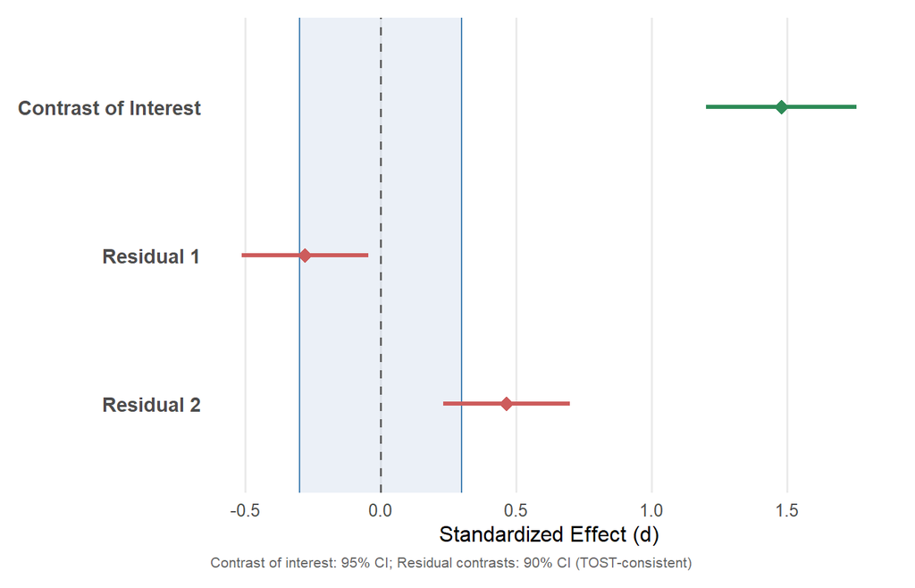

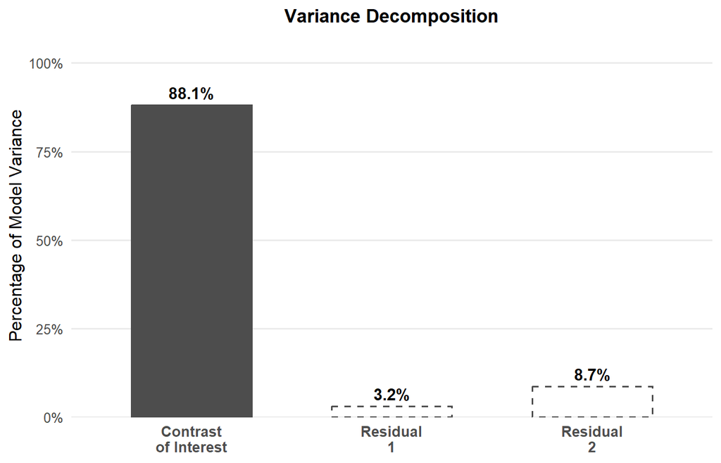

```r
result_drugs <- contrast_analysis(
  data       = data_drugs,
  dv         = "symptom_relief",
  conditions = "treatment",
  hypothesis = c(Placebo = 0, DrugA = 1, DrugB = 1, DrugC = 1),
  delta      = 0.3,
  graph1     = TRUE,
  graph2     = TRUE
)
```

**Reading the output.** The “Hypothesized pattern” line should read `Placebo < [DrugA = DrugB = DrugC]`. With *k* = 4, there are 2 residual contrasts. Because the drugs are predicted to be equal, the residuals test whether the drugs differ from each other. If both residuals are equivalent to zero, the data support the claim that all three drugs are equally effective.

## 5.2 Example 2: Between-subjects with non-linear spacing

**Scenario.** A study on pricing psychology examines willingness to pay (WTP) across four price anchors: $10, $25, $50, and $100. The researcher predicts that WTP scales with the log of the anchor — a concave (diminishing returns) pattern — not linearly with the raw price.

```r
data_pricing <- data.frame(
  anchor = rep(c("$10", "$25", "$50", "$100"), each = 70),
  wtp    = c(
    rnorm(70, mean = 12, sd = 5),
    rnorm(70, mean = 22, sd = 5),
    rnorm(70, mean = 28, sd = 5),
    rnorm(70, mean = 32, sd = 5)
  )
)
```

The hypothesis values encode the predicted non-linear relationship. Here, we use the log of the anchor prices as the predicted means:

```
##
## =================================================================
##       CONTRAST ANALYSIS WITH EQUIVALENCE TESTING
## =================================================================
##
## Design:  between-subjects
## Groups:  $10, $25, $50, $100 (k = 4)
## N:       280
## Alpha:   0.05
## Orthogonal contrasts: Yes
## Effect size metric: d = b / sigma (b = contrast coefficient, sigma = sqrt(MSE))
##
## Hypothesized pattern: $10 < $25 < $50 < $100
##
## ----- Contrast Weights -----
##                 InterestResidual 1Residual 2
##   $10            -0.7084    0.0356    0.4969
##   $25            -0.1706   -0.4604   -0.7134
##   $50             0.2361    0.8025   -0.2240
##   $100            0.6429   -0.3777    0.4404
##
##   Note: Residual contrasts are one possible orthonormal basis for the
##   subspace orthogonal to the predicted pattern. Individual residual
##   vectors are not uniquely defined, but their joint test is invariant:
##   if any systematic deviation from the predicted pattern exists, at
##   least one residual will detect it.
##
## ----- Contrast of Interest (NHST) -----
##   b = 15.122, SE = 0.626, t(276) = 24.156, p < .001 [SIGNIFICANT]
##   d = 2.887, 95% CI [2.652, 3.123]
##
## ----- Residual Contrasts (TOST Equivalence Tests) -----
##   Equivalence bounds (standardized): +/-0.300, +/-0.300
##
##   Residual 1:
##     Weights: $10: +0.036, $25: -0.460, $50: +0.803, $100: -0.378
##     NHST: b = 0.910, SE = 0.626, t(276) = 1.453, p = 0.147
##     TOST: d = 0.174, 90% CI [-0.024, 0.371]
##           p1 < .001, p2 = 0.146, p_TOST = 0.146 [NOT equivalent]
##
```

[output cut: 9 more lines]

```
##   Residual 2:           3.1%
##
## =================================================================
##   CONCLUSION: PARTIALLY SUPPORTED
## =================================================================
##   The data partially support the hypothesized pattern. The
##   contrast of interest is statistically significant, but not all
##   residual contrasts could be declared equivalent to zero. The
##   hypothesized pattern does not fully account for the
##   between-condition differences.
##
## ----- APA-Formatted Results -----
## Contrast of interest: b = 15.12, SE = 0.63, t(276) = 24.16, p < .001, d = 2.89, 95% CI [2.65, 3.12].
## Residual contrast 1 (TOST): b = 0.91, SE = 0.63, d = 0.17, 90% CI [-0.02, 0.37], equivalence bounds = +/-0.30, t1(276) = 3.96, p1 < .001, t2(276) = -1.06, p2 = .146, p_TOST = .146 (not equivalent to zero).
## Residual contrast 2 (TOST): b = -2.73, SE = 0.63, d = -0.52, 90% CI [-0.72, -0.32], equivalence bounds = +/-0.30, t1(276) = -1.84, p1 = .967, t2(276) = -6.86, p2 < .001, p_TOST = .967 (not equivalent to zero).
```

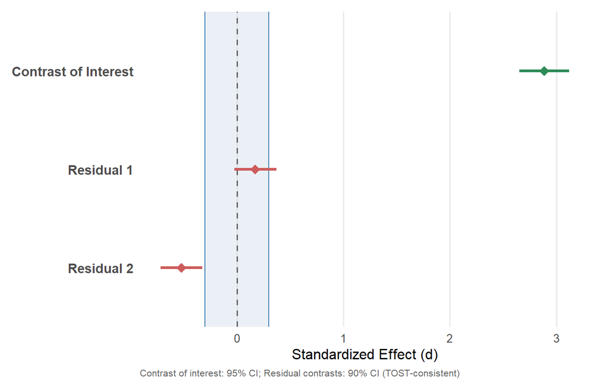

```r
# log(10) = 2.30, log(25) = 3.22, log(50) = 3.91, log(100) = 4.61
result_pricing <- contrast_analysis(
  data       = data_pricing,
  dv         = "wtp",
  conditions = "anchor",
  hypothesis = c(`$10` = log(10), `$25` = log(25),
                 `$50` = log(50), `$100` = log(100)),
  delta      = 0.3,
  graph1     = TRUE,
  graph2     = FALSE
)
```

**Why this matters.** If you had naively used `c(10, 25, 50, 100)` as the hypothesis, you would be testing a *linear* relationship between raw price and WTP. But a linear pattern predicts equal dollar increments in WTP for each dollar increment in anchor, which is not what diminishing returns looks like. By using `log()` values, the contrast weights appropriately down-weight the gap between $50 and $100 relative to the gap between $10 and $25, matching the theoretical prediction.

This is the power of contrast analysis: **the hypothesis values directly encode your theory**. Use them thoughtfully.

## 5.3 Example 3: Within-subjects with three time points

**Scenario.** Participants complete a cognitive task at three time points: *Baseline*, *Post-Training*, and *Follow-Up*. The researcher predicts improvement from Baseline to Post-Training, with maintenance at Follow-Up: Baseline < [Post-Training = Follow-Up].

```r
n <- 60
Sigma_time <- matrix(c(
  16, 10, 10,
  10, 16, 12,
  10, 12, 16
), nrow = 3)

time_scores <- MASS::mvrnorm(n, mu = c(50, 60, 59), Sigma = Sigma_time)

data_time <- data.frame(
  pid       = 1:n,
  Baseline  = time_scores[, 1],
  PostTrain = time_scores[, 2],
  FollowUp  = time_scores[, 3]
)
```

The equality constraint between Post-Training and Follow-Up encodes the prediction that gains are maintained:

```
##
## =================================================================
##       CONTRAST ANALYSIS WITH EQUIVALENCE TESTING
## =================================================================
##
## Design:  within-subjects
## Groups:  Baseline, PostTrain, FollowUp (k = 3)
## N:       60
## Alpha:   0.05
## Orthogonal contrasts: Yes
## Effect size metric: d_z = M / SD (M and SD of within-subject contrast scores)
##
## Hypothesized pattern: Baseline < [PostTrain = FollowUp]
##
## ----- Contrast Weights -----
##                 InterestResidual 1
##   Baseline       -0.8165    0.0000
##   PostTrain       0.4082   -0.7071
##   FollowUp        0.4082    0.7071
##
##   Note: Residual contrasts are one possible orthonormal basis for the
##   subspace orthogonal to the predicted pattern. Individual residual
##   vectors are not uniquely defined, but their joint test is invariant:
##   if any systematic deviation from the predicted pattern exists, at
##   least one residual will detect it.
##
## ----- Contrast of Interest (NHST) -----
##   b = 7.718, SE = 0.349, t(59) = 22.084, p < .001 [SIGNIFICANT]
##   d = 2.851, 95% CI [2.270, 3.432]
##
## ----- Residual Contrasts (TOST Equivalence Tests) -----
##   Equivalence bounds (standardized): +/-0.200
##
##   Residual 1:
##     Weights: Baseline: +0.000, PostTrain: -0.707, FollowUp: +0.707
##     NHST: b = -0.896, SE = 0.296, t(59) = -3.028, p = 0.004
##     TOST: d = -0.391, 90% CI [-0.615, -0.167]
##           p1 = 0.928, p2 < .001, p_TOST = 0.928 [NOT equivalent]
##
## ----- Variance Decomposition -----
##   Contrast of Interest: 98.7%
##   Residual 1:           1.3%
##
## =================================================================
##   CONCLUSION: PARTIALLY SUPPORTED
## =================================================================
##   The data partially support the hypothesized pattern. The
##   contrast of interest is statistically significant, but not all
##   residual contrasts could be declared equivalent to zero. The
##   hypothesized pattern does not fully account for the
##   between-condition differences.
##
## ----- APA-Formatted Results -----
## Contrast of interest: b = 7.72, SE = 0.35, t(59) = 22.08, p < .001, d = 2.85, 95% CI [2.27, 3.43].
## Residual contrast 1 (TOST): b = -0.90, SE = 0.30, d = -0.39, 90% CI [-0.61, -0.17], equivalence bounds = +/-0.20, t1(59) = -1.48, p1 = .928, t2(59) = -4.58, p2 < .001, p_TOST = .928 (not equivalent to zero).
```

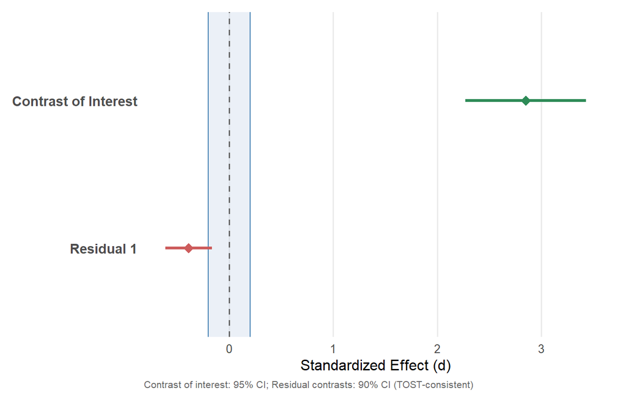

```r
result_time <- contrast_analysis(
  data       = data_time,
  dv         = NULL,
  conditions = NULL,
  hypothesis = c(Baseline = 0, PostTrain = 1, FollowUp = 1),
  design     = "within",
  id         = "pid",
  delta      = 0.2,
  graph1     = TRUE,
  graph2     = FALSE
)
```

**What the residual tests.** With *k* = 3, there is a single residual contrast. Given the hypothesis `Baseline < [PostTrain = FollowUp]`, the residual captures the difference between PostTrain and FollowUp. If it is equivalent to zero, the data support the claim that the training gains are maintained at follow-up.

## 5.4 Example 4: Within-subjects with a step function

**Scenario.** Participants view faces displaying four levels of emotional intensity — *Neutral*, *Mild*, *Moderate*, and *Intense* — and we measure amygdala activation (via fMRI). The theory predicts a threshold effect: activation stays flat for Neutral and Mild, then jumps and stays elevated for Moderate and Intense.

```r
n <- 45
Sigma_fmri <- matrix(0.3, nrow = 4, ncol = 4)
diag(Sigma_fmri) <- 1
Sigma_fmri <- 0.8^2 * Sigma_fmri

fmri_scores <- MASS::mvrnorm(n, mu = c(1.0, 1.1, 2.5, 2.6), Sigma = Sigma_fmri)

data_fmri <- data.frame(
  pid      = 1:n,
  Neutral  = fmri_scores[, 1],
  Mild     = fmri_scores[, 2],
  Moderate = fmri_scores[, 3],
  Intense  = fmri_scores[, 4]
)
```

The hypothesis encodes the step function: the two low conditions share one value, and the two high conditions share another:

```
##
## =================================================================
##       CONTRAST ANALYSIS WITH EQUIVALENCE TESTING
## =================================================================
##
## Design:  within-subjects
## Groups:  Neutral, Mild, Moderate, Intense (k = 4)
## N:       45
## Alpha:   0.05
## Orthogonal contrasts: Yes
## Effect size metric: d_z = M / SD (M and SD of within-subject contrast scores)
##
## Hypothesized pattern: [Neutral = Mild] < [Moderate = Intense]
##
## ----- Contrast Weights -----
##                 InterestResidual 1Residual 2
##   Neutral        -0.5000   -0.5000   -0.5000
##   Mild           -0.5000    0.5000    0.5000
##   Moderate        0.5000    0.5000   -0.5000
##   Intense         0.5000   -0.5000    0.5000
##
##   Note: Residual contrasts are one possible orthonormal basis for the
##   subspace orthogonal to the predicted pattern. Individual residual
##   vectors are not uniquely defined, but their joint test is invariant:
##   if any systematic deviation from the predicted pattern exists, at
##   least one residual will detect it.
##
## ----- Contrast of Interest (NHST) -----
##   b = 1.595, SE = 0.093, t(44) = 17.137, p < .001 [SIGNIFICANT]
##   d = 2.555, 95% CI [1.934, 3.175]
##
## ----- Residual Contrasts (TOST Equivalence Tests) -----
##   Equivalence bounds (standardized): +/-0.250, +/-0.250
##
##   Residual 1:
##     Weights: Neutral: -0.500, Mild: +0.500, Moderate: +0.500, Intense: -0.500
##     NHST: b = 0.023, SE = 0.080, t(44) = 0.292, p = 0.772
##     TOST: d = 0.043, 90% CI [-0.207, 0.294]
##           p1 = 0.028, p2 = 0.086, p_TOST = 0.086 [NOT equivalent]
##
```

[output cut: 9 more lines]

```
##   Residual 2:           0.1%
##
## =================================================================
##   CONCLUSION: PARTIALLY SUPPORTED
## =================================================================
##   The data partially support the hypothesized pattern. The
##   contrast of interest is statistically significant, but not all
##   residual contrasts could be declared equivalent to zero. The
##   hypothesized pattern does not fully account for the
##   between-condition differences.
##
## ----- APA-Formatted Results -----
## Contrast of interest: b = 1.59, SE = 0.09, t(44) = 17.14, p < .001, d = 2.55, 95% CI [1.93, 3.17].
## Residual contrast 1 (TOST): b = 0.02, SE = 0.08, d = 0.04, 90% CI [-0.21, 0.29], equivalence bounds = +/-0.25, t1(44) = 1.97, p1 = .028, t2(44) = -1.39, p2 = .086, p_TOST = .086 (not equivalent to zero).
## Residual contrast 2 (TOST): b = 0.04, SE = 0.12, d = 0.05, 90% CI [-0.20, 0.30], equivalence bounds = +/-0.25, t1(44) = 2.02, p1 = .025, t2(44) = -1.33, p2 = .095, p_TOST = .095 (not equivalent to zero).
```

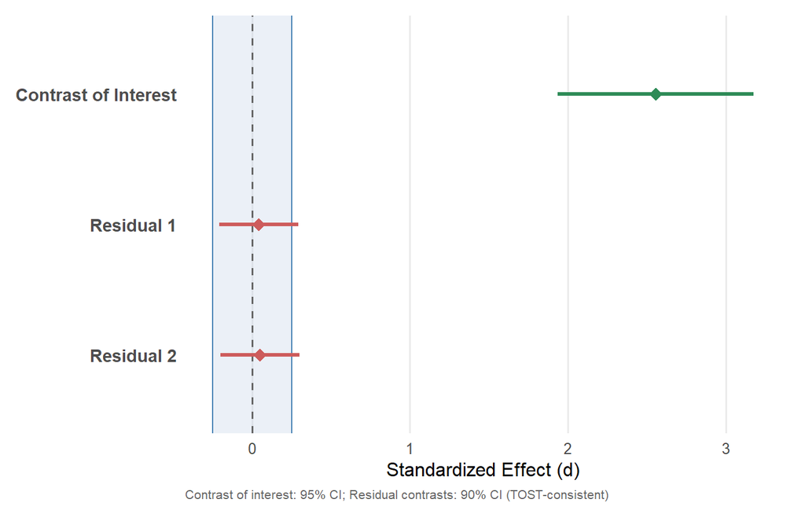

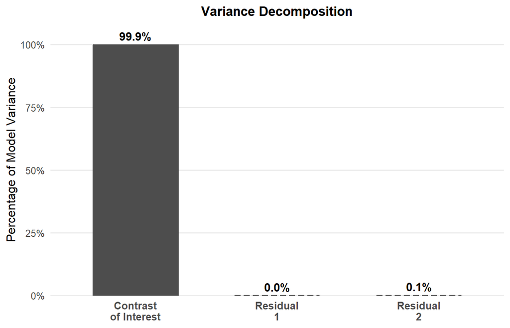

```r
result_fmri <- contrast_analysis(
  data       = data_fmri,
  dv         = NULL,
  conditions = NULL,
  hypothesis = c(Neutral = 0, Mild = 0, Moderate = 1, Intense = 1),
  design     = "within",
  id         = "pid",
  delta      = 0.25,
  graph1     = TRUE,
  graph2     = TRUE
)
```

**What the residuals test.** With *k* = 4 and a step-function hypothesis, there are 2 residual contrasts. Together, they capture two kinds of deviation from the step model: (a) any difference between Neutral and Mild (which should be equal), and (b) any difference between Moderate and Intense (which should also be equal). If both are equivalent to zero, the step function is a sufficient description of the activation pattern.

## 5.5 Example 5: Within-subjects, k = 5, linear trend

**Scenario.** A learning experiment measures recall accuracy across five study sessions. The theory predicts a steady linear improvement.

```r
n <- 55
k <- 5
Sigma_learn <- matrix(0.5, k, k)
diag(Sigma_learn) <- 1
Sigma_learn <- 4^2 * Sigma_learn

learn_scores <- MASS::mvrnorm(n, mu = c(40, 48, 56, 64, 72), Sigma = Sigma_learn)

data_learn <- data.frame(
  pid = 1:n,
  S1  = learn_scores[, 1],
  S2  = learn_scores[, 2],
  S3  = learn_scores[, 3],
  S4  = learn_scores[, 4],
  S5  = learn_scores[, 5]
)
```

```
##
## =================================================================
##       CONTRAST ANALYSIS WITH EQUIVALENCE TESTING
## =================================================================
##
## Design:  within-subjects
## Groups:  S1, S2, S3, S4, S5 (k = 5)
## N:       55
## Alpha:   0.05
## Orthogonal contrasts: Yes
## Effect size metric: d_z = M / SD (M and SD of within-subject contrast scores)
##
## Hypothesized pattern: S1 < S2 < S3 < S4 < S5
##
## ----- Contrast Weights -----
##                 InterestResidual 1Residual 2Residual 3
##   S1             -0.6325   -0.4149   -0.3626   -0.3104
##   S2             -0.3162    0.0672    0.3996    0.7320
##   S3              0.0000    0.8377   -0.2013   -0.2403
##   S4              0.3162   -0.2174    0.6543   -0.4739
##   S5              0.6325   -0.2726   -0.4900    0.2925
##
##   Note: Residual contrasts are one possible orthonormal basis for the
##   subspace orthogonal to the predicted pattern. Individual residual
##   vectors are not uniquely defined, but their joint test is invariant:
##   if any systematic deviation from the predicted pattern exists, at
##   least one residual will detect it.
##
## ----- Contrast of Interest (NHST) -----
##   b = 25.856, SE = 0.393, t(54) = 65.855, p < .001 [SIGNIFICANT]
##   d = 8.880, 95% CI [7.161, 10.599]
##
## ----- Residual Contrasts (TOST Equivalence Tests) -----
##   Equivalence bounds (standardized): +/-0.300, +/-0.300, +/-0.300
##
##   Residual 1:
##     Weights: S1: -0.415, S2: +0.067, S3: +0.838, S4: -0.217, S5: -0.273
##     NHST: b = 0.141, SE = 0.361, t(54) = 0.391, p = 0.698
##     TOST: d = 0.053, 90% CI [-0.173, 0.278]
##           p1 = 0.006, p2 = 0.036, p_TOST = 0.036 [EQUIVALENT (within bounds)]
```

[output cut: 18 more lines]

```
##
## =================================================================
##   CONCLUSION: PARTIALLY SUPPORTED
## =================================================================
##   The data partially support the hypothesized pattern. The
##   contrast of interest is statistically significant, but not all
##   residual contrasts could be declared equivalent to zero. The
##   hypothesized pattern does not fully account for the
##   between-condition differences.
##
## ----- APA-Formatted Results -----
## Contrast of interest: b = 25.86, SE = 0.39, t(54) = 65.86, p < .001, d = 8.88, 95% CI [7.16, 10.60].
## Residual contrast 1 (TOST): b = 0.14, SE = 0.36, d = 0.05, 90% CI [-0.17, 0.28], equivalence bounds = +/-0.30, t1(54) = 2.62, p1 = .006, t2(54) = -1.83, p2 = .036, p_TOST = .036 (equivalent to zero).
## Residual contrast 2 (TOST): b = 0.36, SE = 0.35, d = 0.14, 90% CI [-0.09, 0.37], equivalence bounds = +/-0.30, t1(54) = 3.26, p1 < .001, t2(54) = -1.19, p2 = .120, p_TOST = .120 (not equivalent to zero).
## Residual contrast 3 (TOST): b = -0.23, SE = 0.40, d = -0.08, 90% CI [-0.30, 0.15], equivalence bounds = +/-0.30, t1(54) = 1.65, p1 = .053, t2(54) = -2.80, p2 = .004, p_TOST = .053 (not equivalent to zero).
```

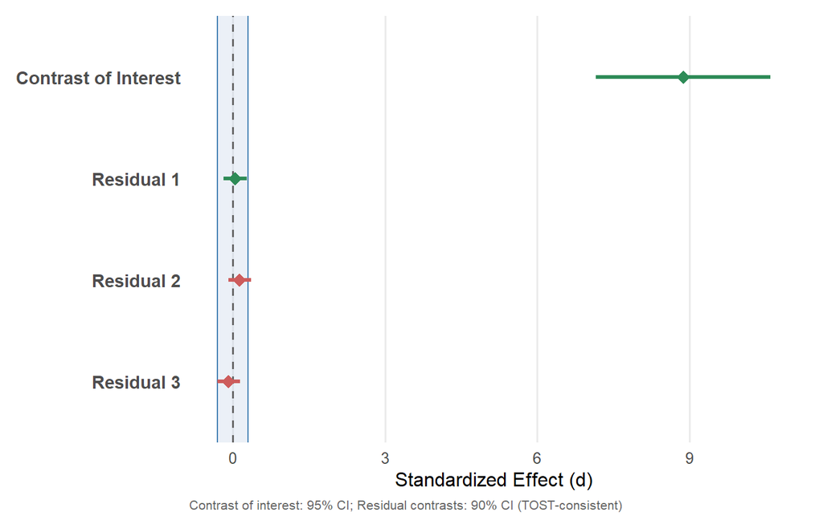

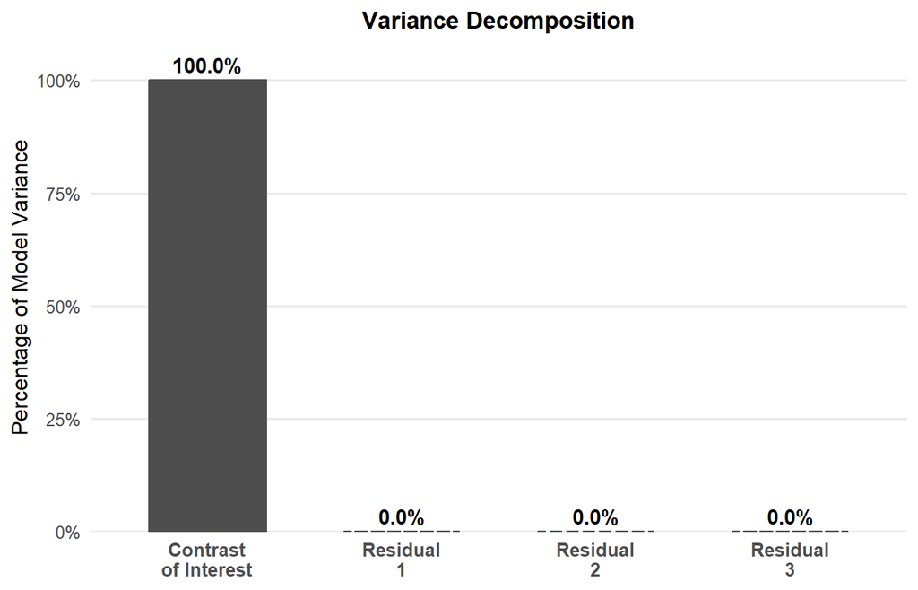

```r
result_learn <- contrast_analysis(
  data       = data_learn,
  dv         = NULL,
  conditions = NULL,
  hypothesis = c(S1 = 1, S2 = 2, S3 = 3, S4 = 4, S5 = 5),
  design     = "within",
  id         = "pid",
  delta      = 0.3,
  graph1     = TRUE,
  graph2     = TRUE
)
```

**What to look for.** With *k* = 5, there are 3 residual contrasts. A linear hypothesis predicts equal increments between sessions. The residuals collectively capture any curvature, plateaus, or irregular jumps. If the learning curve is truly linear, all three residuals should be equivalent to zero.

## 5.6 Example 6: Between-subjects with `share_signal`

**Scenario.** The same aggression study from Part 1, but now the researcher wants to define “negligible” residuals in terms of percentage of explained variance rather than raw *d* units.

```
##
## =================================================================
##       CONTRAST ANALYSIS WITH EQUIVALENCE TESTING
## =================================================================
##
## Design:  between-subjects
## Groups:  None, Mild, Moderate, Extreme (k = 4)
## N:       240
## Alpha:   0.05
## Orthogonal contrasts: Yes
## Effect size metric: d = b / sigma (b = contrast coefficient, sigma = sqrt(MSE))
##
## Hypothesized pattern: None < Mild < Moderate < Extreme
##
## ----- Contrast Weights -----
##                 InterestResidual 1Residual 2
##   None           -0.6708   -0.4236   -0.3472
##   Mild           -0.2236    0.3060    0.7787
##   Moderate        0.2236    0.6588   -0.5157
##   Extreme         0.6708   -0.5412    0.0843
##
##   Note: Residual contrasts are one possible orthonormal basis for the
##   subspace orthogonal to the predicted pattern. Individual residual
##   vectors are not uniquely defined, but their joint test is invariant:
##   if any systematic deviation from the predicted pattern exists, at
##   least one residual will detect it.
##
## ----- Contrast of Interest (NHST) -----
##   b = 3.281, SE = 0.316, t(236) = 10.382, p < .001 [SIGNIFICANT]
##   d = 1.340, 95% CI [1.086, 1.595]
##
## ----- Residual Contrasts (TOST Equivalence Tests) -----
##   Delta type: share_signal (% of model variance)
##   Reference d_interest_min: 0.5
##   Equivalence bounds (converted to d-scale):
##     Residual 1: max share = 5.0% => d bound = +/-0.1147
##     Residual 2: max share = 5.0% => d bound = +/-0.1147
##
##   Residual 1:
##     Weights: None: -0.424, Mild: +0.306, Moderate: +0.659, Extreme: -0.541
```

[output cut: 23 more lines]

```
##   implicitly (interest must be significant for SUPPORTED).
##
## =================================================================
##   CONCLUSION: PARTIALLY SUPPORTED
## =================================================================
##   The data partially support the hypothesized pattern. The
##   contrast of interest is statistically significant, but not all
##   residual contrasts could be declared equivalent to zero. The
##   hypothesized pattern does not fully account for the
##   between-condition differences.
##
## ----- APA-Formatted Results -----
## Contrast of interest: b = 3.28, SE = 0.32, t(236) = 10.38, p < .001, d = 1.34, 95% CI [1.09, 1.59].
## Residual contrast 1 (TOST): b = -0.50, SE = 0.32, d = -0.20, 90% CI [-0.42, 0.01], equivalence bounds = +/-0.115 (from 5.0% share, d_int_min = 0.50), t1(236) = -0.69, p1 = .754, t2(236) = -2.46, p2 = .007, p_TOST = .754 (not equivalent to zero).
## Residual contrast 2 (TOST): b = -0.37, SE = 0.32, d = -0.15, 90% CI [-0.36, 0.06], equivalence bounds = +/-0.115 (from 5.0% share, d_int_min = 0.50), t1(236) = -0.29, p1 = .612, t2(236) = -2.06, p2 = .020, p_TOST = .612 (not equivalent to zero).
```

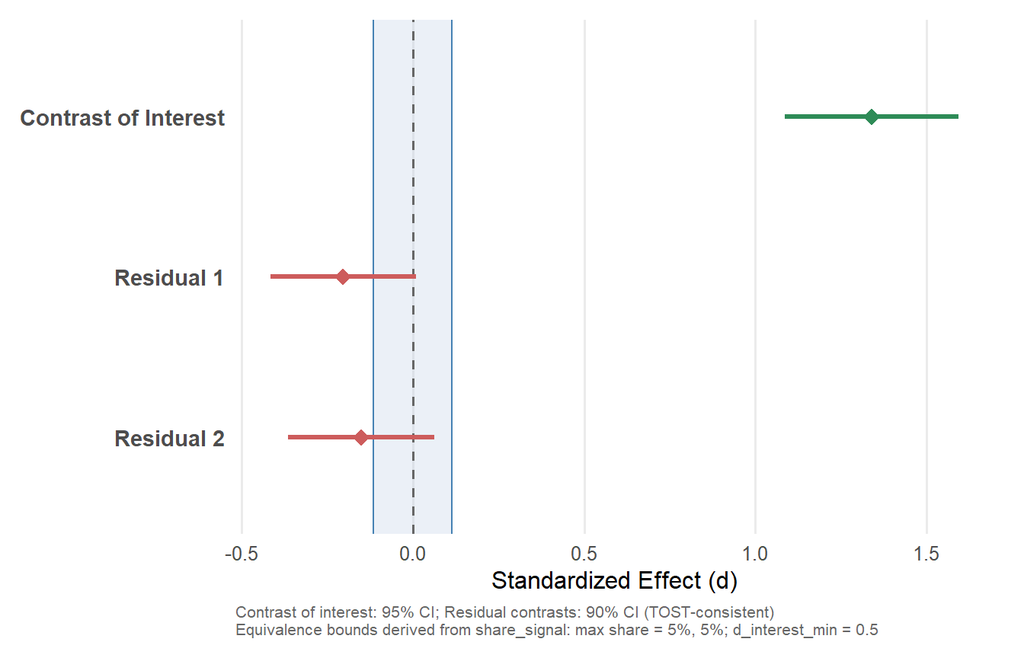

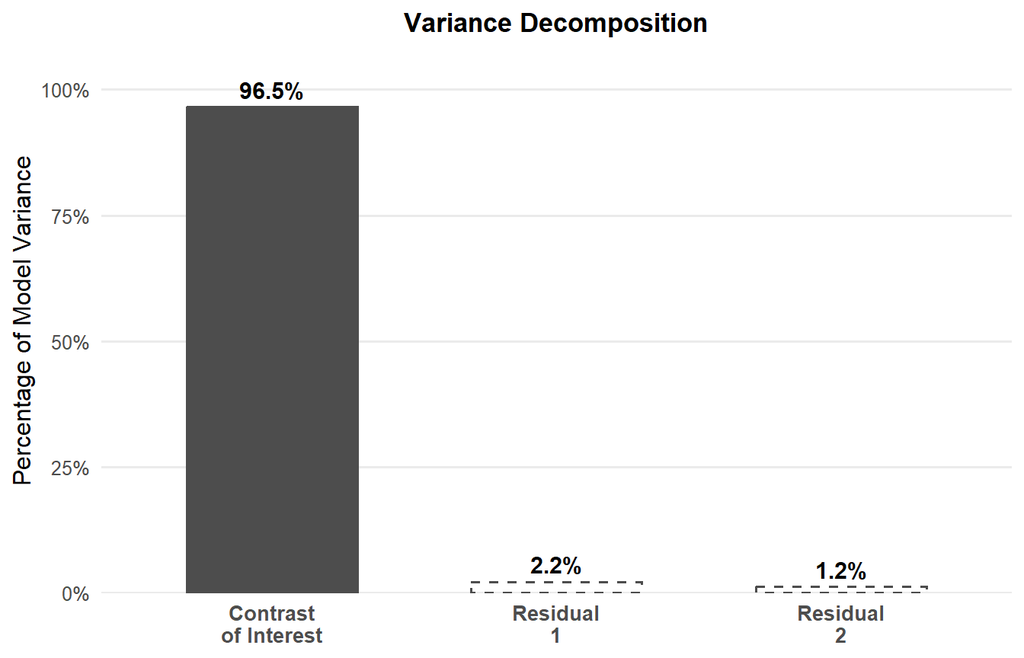

```r
result_share <- contrast_analysis(
  data       = data_between,
  dv         = "aggression",
  conditions = "condition",
  hypothesis = c(None = 0, Mild = 1, Moderate = 2, Extreme = 3),
  delta      = 5,
  delta_type = "share_signal",
  d_interest_min = 0.50,
  graph1     = TRUE,
  graph2     = TRUE
)
```

The equivalence bound section of the output now shows the conversion:

# 6 Part 5: Common Mistakes and How to Fix Them

### 6.0.1 Mistake 1: Using long format for within-subjects

```r
# This will NOT work:
data_long_wrong <- data.frame(
  pid       = rep(1:50, each = 3),
  condition = rep(c("A", "B", "C"), times = 50),
  score     = rnorm(150)
)

# This tries to treat it as between-subjects (each row = separate person)
# The pid column is ignored and you get wrong results.
# You must pivot to wide format first!
```

**Fix:** Use `reshape()` or `tidyr::pivot_wider()` to convert to wide format before calling `contrast_analysis()` with `design = "within"`.

### 6.0.2 Mistake 2: Forgetting `design = "within"`

If you have wide-format data but forget to set `design = "within"`, the function defaults to between-subjects and tries to look for `dv` and `conditions` columns. You will get an error because those columns do not exist.

```r
# Forgetting design = "within":
contrast_analysis(
  data_within, dv = NULL, conditions = NULL,
  hypothesis = c(Puzzle = 0, Action = 1, Violent = 2),
  delta = 0.3
  # Missing: design = "within", id = "pid"
)
```

**Fix:** Always set `design = "within"` and `id = "pid"` (or whatever your ID column is called) for repeated-measures data.

### 6.0.3 Mistake 3: Hypothesis names don’t match column names

For within-subjects, the hypothesis names must exactly match the column names in the data frame. For between-subjects, they must match the levels of the grouping factor.

```r
# Column is "Violent" but hypothesis says "violent" (lowercase):
contrast_analysis(
  data_within, dv = NULL, conditions = NULL,
  hypothesis = c(Puzzle = 0, Action = 1, violent = 2),  # lowercase 'v'
  design = "within", id = "pid", delta = 0.3
)
# Error: hypothesis names do not match condition names
```

**Fix:** Check spelling and case. Use `names(your_data)` for within-subjects or `levels(factor(your_data$group))` for between-subjects to see the exact labels.

### 6.0.4 Mistake 4: Including the ID column in hypothesis names

The participant ID column is *not* a condition. Don’t include it:

```r
# WRONG: "pid" is not a condition
hypothesis = c(pid = 0, Puzzle = 0, Action = 1, Violent = 2)

# CORRECT: only the condition columns
hypothesis = c(Puzzle = 0, Action = 1, Violent = 2)
```

# 7 Part 6: Quick Reference Cheat Sheet

## 7.1 Between-subjects call template

```r
result <- contrast_analysis(
  data       = my_data,
  dv         = "outcome_column",
  conditions = "group_column",
  hypothesis = c(GroupA = 0, GroupB = 1, GroupC = 2),
  design     = "between",      # default, can omit
  delta      = 0.3
)
```

## 7.2 Within-subjects call template

```r
result <- contrast_analysis(
  data       = my_wide_data,
  dv         = NULL,
  conditions = NULL,
  hypothesis = c(Cond1 = 0, Cond2 = 1, Cond3 = 2),
  design     = "within",
  id         = "participant_id_column",
  delta      = 0.3
)
```

## 7.3 Decision flowchart

```
Is the same person measured in every condition?
│
├── YES (within-subjects)
│   ├── Is your data in wide format? (one row per person, one column per condition)
│   │   ├── YES → Use directly
│   │   └── NO  → Pivot to wide first (reshape / pivot_wider)
│   │
│   └── Set: design = "within", dv = NULL, conditions = NULL, id = "pid"
│         hypothesis names = column names
│
└── NO (between-subjects)
    ├── Data should be in long format (one row per observation)
    │
    └── Set: dv = "score", conditions = "group"
          hypothesis names = factor levels of grouping variable
```

## 7.4 Key differences at a glance

| Feature | Between | Within |
| --- | --- | --- |
| Data format | Long (one row per person) | Wide (one row per person) |
| dv | DV column name | NULL |
| conditions | Group column name | NULL |
| design | “between” (default) | “within” |
| id | Not needed | ID column name |
| hypothesis names match… | Levels of grouping factor | Condition column names |
| Effect size | d = b / sqrt(MSE) | d_z = M / SD of contrast scores |
| Degrees of freedom | N - k | n - 1 |
| Underlying test | Regression (lm) | One-sample t on contrast scores |
| Power advantage | — | Removes between-person variance |